# Lecture 12 — Camera Calibration

Lecture 12

Kaveh Fathian

Computer Science Department, Colorado School of Mines

## Learning Objectives

By the end of this lecture, you should be able to:

- Explain what geometric calibration estimates: the intrinsic matrix, the lens distortion, and the target poses.
- Calibrate a camera linearly from a known 3D target, and recover $\mathbf{K}$, ${}^{c}\mathbf{R}_{w}$, and ${}^{c}\mathbf{t}_{w}$ from the camera matrix.
- Describe the reprojection error and the radial–tangential, fisheye, and omnidirectional lens models.
- Calibrate a camera with a checkerboard in OpenCV, and undistort its images.
- Collect useful calibration images, and check the result with per-view reprojection errors.

## What Does It Mean to Calibrate a Camera?

- To **calibrate** is to estimate the parameters of a camera model from measurements. There are many kinds:
  - **Radiometric:** pixel value vs. scene brightness.
  - **Color:** sensor response vs. true color.
  - **Noise:** sensor noise level and pattern.
  - **Lens aberration:** blur, vignetting, chromatic effects.
  - **Geometric:** where each pixel looks in 3D.
- This lecture covers **geometric calibration**. It estimates:
  - The **intrinsic matrix** $\mathbf{K}$
  - The **lens distortion** coefficients
  - The **pose** of the target in each image

[figure not shown]

$$\underbrace{\lambda}_{\text{depth } Z_c}\,
\underbrace{\mathbf{x}}_{\substack{\text{pixel}\\ (u,\,v,\,1)}}
=
\overbrace{
\underbrace{\color{#c53030}{\mathbf{K}}}_{\substack{\text{intrinsic}\\ \text{matrix}}}\;
\underbrace{\big[\,{}^{c}\mathbf{R}_{w} \mid {}^{c}\mathbf{t}_{w}\,\big]}_{\substack{\text{extrinsic}\\ \text{matrix}}}
}^{\mathbf{P}:\ \text{camera matrix}}\;
\underbrace{{}^{w}\mathbf{X}}_{\substack{\text{world point}\\ (X,\,Y,\,Z,\,1)}}$$

## Problems Based on Camera Model

$$\lambda\,\mathbf{x} = \mathbf{K}\,\big[\,{}^{c}\mathbf{R}_{w} \mid {}^{c}\mathbf{t}_{w}\,\big]\;{}^{w}\mathbf{X}$$

Which quantities are known and which are unknown defines the problem:

| Problem | Pixels $\mathbf{x}$ | Intrinsics $\mathbf{K}$ | Extrinsics ${}^{c}\mathbf{R}_{w},\ {}^{c}\mathbf{t}_{w}$ | 3D points ${}^{w}\mathbf{X}$ |
| --- | --- | --- | --- | --- |
| Projection (simulate a camera) | unknown | known | known | known |
| **Camera calibration** | known | unknown | unknown | known |
| Two-view geometry | known | known | unknown | unknown |
| Triangulation | known | known | known | unknown |

- Calibration is usually done **once** per camera and lens setting. The estimated/known $\mathbf{K}$ and distortion are then used in other problems.
- Calibration is also called **resectioning**.

## Linear Calibration with a Known 3D Target

- Assume given an image of a **target** whose 3D points ${}^{w}\mathbf{X}_i$ are known, with their pixel positions $(u_i, v_i)$.
- Unknown: the camera matrix $\mathbf{P}$, with rows $\mathbf{p}_1^{T}, \mathbf{p}_2^{T}, \mathbf{p}_3^{T}$.
- From camera model $\lambda\,\begin{bmatrix} u_i \\ v_i \\ 1 \end{bmatrix} = \begin{bmatrix} \mathbf{p}_1^{T} \\ \mathbf{p}_2^{T} \\ \mathbf{p}_3^{T} \end{bmatrix}\,{}^{w}\mathbf{X}_i,$ we have:
  $$\lambda u_i = \mathbf{p}_1^{T}\,{}^{w}\mathbf{X}_i,
  \qquad
  \lambda v_i = \mathbf{p}_2^{T}\,{}^{w}\mathbf{X}_i,
  \qquad
  \lambda = \mathbf{p}_3^{T}\,{}^{w}\mathbf{X}_i$$
- Substituting $\lambda=\mathbf{p}_3^{T}\,{}^{w}\mathbf{X}_i$ in the first two equations gives **two equations per point**, both **linear** in the 12 entries of $\mathbf{P}$:
  $$\mathbf{p}_1^{T}\,{}^{w}\mathbf{X}_i - u_i\,\mathbf{p}_3^{T}\,{}^{w}\mathbf{X}_i = 0$$
  $$\mathbf{p}_2^{T}\,{}^{w}\mathbf{X}_i - v_i\,\mathbf{p}_3^{T}\,{}^{w}\mathbf{X}_i = 0$$

[figure not shown]

## Direct Linear Transform (DLT)

- Stack the two rows of every point into $\mathbf{A}$ and solve $\mathbf{A}\mathbf{p} = \mathbf{0}$ with the SVD:
  $$\underbrace{\begin{bmatrix}
  {}^{w}\mathbf{X}_1^{T} & \mathbf{0}^{T} & -u_1\,{}^{w}\mathbf{X}_1^{T} \\
  \mathbf{0}^{T} & {}^{w}\mathbf{X}_1^{T} & -v_1\,{}^{w}\mathbf{X}_1^{T} \\
  \vdots & \vdots & \vdots
  \end{bmatrix}}_{\mathbf{A}:\ 2N \times 12}
  \underbrace{\begin{bmatrix} \mathbf{p}_1 \\ \mathbf{p}_2 \\ \mathbf{p}_3 \end{bmatrix}}_{12 \times 1}
  = \mathbf{0}$$
- $\mathbf{P}$ has **11 DOF** and each point gives 2 equations: at least **6 points**, not all on one plane.
- The more points we use, the more robust the solution is to noise as it is averaged out.
- $\mathbf{P}$ and $-\mathbf{P}$ are both solutions; keep the sign that puts the points **in front** of the camera.

```python
def calibrate_dlt(X_w, uv):
    A = []
    for X, (u, v) in zip(X_w, uv):
        X_h = np.append(X, 1)
        z = np.zeros(4)
        A += [np.r_[X_h, z, -u * X_h],
              np.r_[z, X_h, -v * X_h]]
    _, _, Vt = np.linalg.svd(np.array(A))
    P = Vt[-1].reshape(3, 4)
    if np.linalg.det(P[:, :3]) < 0:
        P = -P
    return P
```

Example output for the target points of the previous slide:

$$\mathbf{P}_{\text{DLT}} = \begin{bmatrix} -0.487 & 0.221 & -0.202 & 0.483 \\ 0.108 & 0.0902 & -0.514 & 0.395 \\ -0.000563 & -0.000466 & -0.000631 & 0.00157 \end{bmatrix}$$

## Least-Squares Review (Supplementary)

- When we have more equations than unknowns (plus noise), there is no exact solution. Least-squares find the best approximate solution that minimizes the sum of squared errors. There are two cases:
- **Nonhomogeneous** $\mathbf{A}\mathbf{p} = \mathbf{b}$:
  $$\min_{\mathbf{p}} \|\mathbf{A}\mathbf{p} - \mathbf{b}\|^2
  \;\Rightarrow\;
  \mathbf{p} = (\mathbf{A}^{T}\mathbf{A})^{-1}\mathbf{A}^{T}\mathbf{b}$$
- **Homogeneous** $\mathbf{A}\mathbf{p} = \mathbf{0}$:
  - $\mathbf{p} = \mathbf{0}$ is trivial, and any scaled solution is a solution, so fix the scale $\|\mathbf{p}\| = 1$:
    $$\min_{\|\mathbf{p}\| = 1} \|\mathbf{A}\mathbf{p}\|^2\;\Rightarrow\; \mathbf{p} = \text{last right singular vector of } \mathbf{A}$$
- Calibration is the **homogeneous** case: $\mathbf{P}$ is only defined up to scale.
- In NumPy:
  - $\mathbf{A}\mathbf{p} = \mathbf{b} \implies$ `p = np.linalg.lstsq(A, b)[0]`
  - $\mathbf{A}\mathbf{p} = \mathbf{0} \implies$ `p = np.linalg.svd(A)[2][-1]`

## Extracting $\mathbf{K}$, ${}^{c}\mathbf{R}_{w}$, and ${}^{c}\mathbf{t}_{w}$ From $\mathbf{P}$

- The left $3 \times 3$ block of $\mathbf{P}$ is $\mathbf{M} = \mathbf{K}\,{}^{c}\mathbf{R}_{w}$: upper triangular times a rotation.
- **RQ decomposition** splits $\mathbf{M}$ into these two factors (“R” = upper triangular $\mathbf{K}$, “Q” = rotation ${}^{c}\mathbf{R}_{w}$). Signs are fixed so $\mathbf{K}$ has a positive diagonal.
- With $\mathbf{p}_4$ the last column of $\mathbf{P}$:
  $${}^{c}\mathbf{t}_{w} = \mathbf{K}^{-1}\,\mathbf{p}_4,
  \qquad
  {}^{w}\mathbf{C} = -\mathbf{M}^{-1}\,\mathbf{p}_4$$
- OpenCV does all of this:

```python
K_est, R_est, C_h, *_ = cv2.decomposeProjectionMatrix(P_dlt)
K_est = K_est / K_est[2, 2]           # K, normalized so that K[2, 2] = 1
C_est = C_h[:3, 0] / C_h[3, 0]        # camera center wC from homogeneous coordinates
t_est = -R_est @ C_est                # ct_w = -cR_w wC
```

## Limits of Linear Calibration

- **No lens distortion.** A wide-angle lens bends straight lines, which no $\mathbf{P}$ can model.
- **Wrong error.** It minimizes the *algebraic* error $\|\mathbf{A}\mathbf{p}\|$, not the distance in pixels.
- **No constraints.** Known facts, such as $s = 0$, are hard to enforce.
- **Needs a precise 3D target.** If all points lie on one plane ($Z = 0$), the columns of $\mathbf{A}$ that multiply $Z$ are zero, and $\mathbf{p}$ is not unique (right).
- **In practice: Linear calibration is not used**. A linear solution is only the **initial guess**, which is used in nonlinear optimization to refine all parameters, including lens distortion.

[figure not shown]

## Nonlinear Calibration

- Nonlinear calibration compares **observed** image points $\mathbf{x}_i = (u_i, v_i)$ with the points **predicted** by the camera model.
- The **reprojection error** is their distance in **pixels**, summed over all points:
  $$E = \sum_{i}\Big\|\,\mathbf{x}_{i} - \pi\big(\mathbf{K}, \mathbf{d},\, {}^{c}\mathbf{R}_{w},\, {}^{c}\mathbf{t}_{w},\, {}^{w}\mathbf{X}_i\big)\Big\|^2$$
  - $\mathbf{d}$: lens distortion coefficients (next slides).
  - ${}^{c}\mathbf{R}_{w}, {}^{c}\mathbf{t}_{w}$: pose of the target (world frame $w$) in the camera frame.
  - $\pi(\cdot)$: the camera model.
- $E$ is **nonlinear** in the parameters. It is minimized by iterative **nonlinear least squares** (Levenberg–Marquardt), starting from a linear initial guess.
- In practice, the target is imaged in **many views** $j$, and $E$ sums over all of them: one $\mathbf{K}$ and $\mathbf{d}$, plus one pose ${}^{c_j}\mathbf{R}_{w}, {}^{c_j}\mathbf{t}_{w}$ per view.

[figure not shown]

## The Lens Distortion Model

- Distortion acts on the image coordinates, before $\mathbf{K}$:
  $${}^{c}\mathbf{X} \;\to\; (x, y) = \Big(\tfrac{{}^cX}{{}^cZ}, \tfrac{{}^cY}{{}^cZ}\Big) \;\xrightarrow{\text{distortion}}\; (x_d, y_d) \;\xrightarrow{\;\mathbf{K}\;}\; (u, v)$$
  - $(x, y)$: where an ideal **pinhole** camera sees the point.
  - $(x_d, y_d)$: where the **lens** actually puts it.
- With $r^2 = x^2 + y^2$ (squared distance from the principal point):
  $$\begin{aligned}
  x_d &= \underbrace{\color{#2b6cb0}{x\,(1 + k_1 r^2 + k_2 r^4 + k_3 r^6)}}_{\color{#2b6cb0}{\text{radial}}} + \underbrace{\color{#c05621}{2 p_1 x y + p_2 (r^2 + 2 x^2)}}_{\color{#c05621}{\text{tangential}}} \\
  y_d &= \underbrace{\color{#2b6cb0}{y\,(1 + k_1 r^2 + k_2 r^4 + k_3 r^6)}}_{\color{#2b6cb0}{\text{radial}}} + \underbrace{\color{#c05621}{p_1 (r^2 + 2 y^2) + 2 p_2 x y}}_{\color{#c05621}{\text{tangential}}}
  \end{aligned}$$
- Pixels: $(u, v, 1)^{T} = \mathbf{K}\,(x_d, y_d, 1)^{T}$, instead of $\mathbf{K}\,(x, y, 1)^{T}$. This is the camera model $\pi(\cdot)$ of the previous slide.

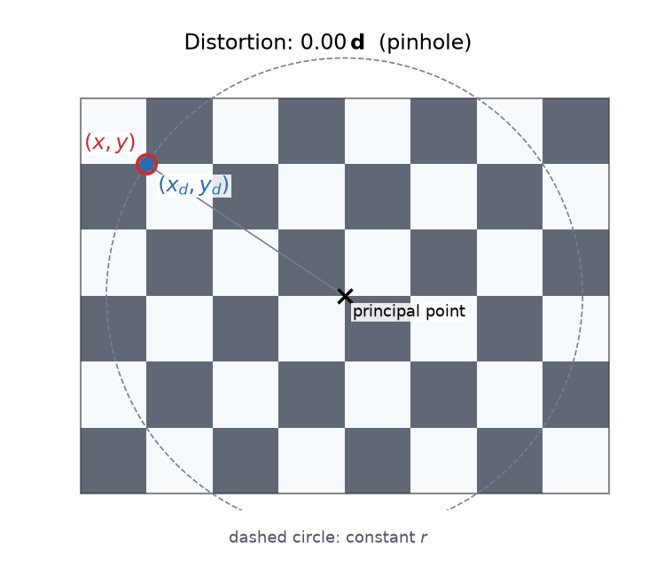

## Radial Distortion

[figure not shown]

- The **radial** terms scale $(x, y)$ along its ray from the principal point: $\begin{bmatrix} x_d \\ y_d \end{bmatrix} = s(r) \begin{bmatrix} x \\ y \end{bmatrix}, \quad s(r) = 1 + k_1 r^2 + k_2 r^4 + k_3 r^6$
- Only the **distance** from the center changes, from $r$ to $r_d = \sqrt{x_d^2 + y_d^2} = r\,s(r)$$
- **Barrel** ($k_1 < 0$, $s < 1$): points move **toward** the center; wide-angle lenses (GoPro, phone ultra-wide).
- **Pincushion** ($k_1 > 0$, $s > 1$): points move **away** from the center; telephoto lenses.
- Straight lines not through the center become **curved**. The effect is $\approx 0$ near the center and **grows** with $r$.

## Tangential Distortion

[figure not shown]

- The **tangential** terms shift points **sideways**, not along their ray from the center:
  $$x_d = x\,s(r) + \underbrace{\color{#c05621}{2 p_1 x y + p_2 (r^2 + 2 x^2)}}_{\color{#c05621}{\Delta x}},
  \qquad
  y_d = y\,s(r) + \underbrace{\color{#c05621}{p_1 (r^2 + 2 y^2) + 2 p_2 x y}}_{\color{#c05621}{\Delta y}}$$
- Cause: lens elements slightly **tilted or off-center** relative to the sensor.
- Usually **small**.

## Wide Lenses: Fisheye and Omnidirectional

- A pinhole maps a ray at angle $\theta$ from the optical axis to radius $r = f \tan\theta$, which grows to **infinity** at $90^\circ$.
- **Fisheye** lenses use a different mapping, close to $r = f\,\theta$, so they can see $180^\circ$ or more.
  - OpenCV `cv2.fisheye`: $\theta_d = \theta\,(1 + k_1\theta^2 + k_2\theta^4 + k_3\theta^6 + k_4\theta^8)$
- **Omnidirectional** cameras: field of view $\geq 180^\circ$, or a curved mirror in front of the lens.
  - OpenCV `cv2.omnidir` unified sphere model, or Scaramuzza’s polynomial model (OCamCalib).
- Rule of thumb: radial–tangential up to a **field of view** (FOV) of about $100^\circ$–$120^\circ$, i.e., $\theta$ up to $50^\circ$–$60^\circ$ at the image edge; beyond that, fisheye or omnidirectional.

[figure not shown]

## Common Calibration Targets

[figure not shown]

| Target | OpenCV detector | Strengths | Weaknesses |
| --- | --- | --- | --- |
| Checkerboard | `findChessboardCorners` | Simple; accurate corners (sub-pixel) | The whole board must be visible |
| Circle grids | `findCirclesGrid` | Robust to blur and noise | Circle centers shift slightly under perspective |
| ChArUco | `cv2.aruco.CharucoDetector` | Each corner is identified by its markers: partial and occluded views still work | Must be printed exactly to spec |

- ChArUco makes it easy to cover image corners, where distortion is largest, because the board may be partly outside the image.
- You must know/measure the **exact size** of the squares/markers in the target to get the correct scale for translation.

## Calibration Example in OpenCV

[figure not shown]

- $35$ images from a GoPro camera with a wide-angle lens, $1280 × 960$ pixels.
- Checkerboard with $9×7$ squares, so $8×6=48$ **inner corners**.
- Square size: $80\,\text{mm}$.

## Step 1: Detect the Corners

```python
img = cv2.imread(str(calib_dir / "GOPR0046.jpg"))
gray = cv2.cvtColor(img, cv2.COLOR_BGR2GRAY)
pattern = (8, 6)  # inner corners per row, per column
found, corners = cv2.findChessboardCorners(gray, pattern)

criteria = (cv2.TERM_CRITERIA_EPS
            + cv2.TERM_CRITERIA_MAX_ITER, 30, 1e-3)
corners_sub = cv2.cornerSubPix(gray, corners.copy(),
                               (11, 11), (-1, -1), criteria)
```

- `corners`: the 48 corner pixels, ordered **row by row**, starting at one end of the board.
- `cornerSubPix` refines each corner to **sub-pixel** accuracy using the image gradients in an $11 \times 11$ window. It works in place, hence the `.copy()` here.
- If `found` is `False`, skip the image: the board was not fully visible.

[figure not shown]

## Step 2: Match Corners to Board Points

```python
square = 80.0  # mm
objp = np.zeros((pattern[0] * pattern[1], 3), np.float32)
objp[:, :2] = np.mgrid[0:8, 0:6].T.reshape(-1, 2) * square

obj_points, img_points = [], []
for path in calib_files:
    gray = cv2.imread(str(path), cv2.IMREAD_GRAYSCALE)
    found, corners = cv2.findChessboardCorners(gray,
                                               pattern)
    if not found:
        continue
    corners = cv2.cornerSubPix(gray, corners, (11, 11),
                               (-1, -1), criteria)
    obj_points.append(objp)
    img_points.append(corners)
```

- `objp` holds the corners ${}^{b}\mathbf{X}_i = (X, Y, 0)$ in the **board frame** $b$, in the **same order** as the detected corners.
- The board frame moves with the board, so `objp` is the same for every view.

[figure not shown]

## Step 3: Calibrate

```python
rms, K, dist, rvecs, tvecs = cv2.calibrateCamera(
    obj_points, img_points, image_size, None, None)
```

- Inside: a linear initial guess (Zhang’s method), then **Levenberg–Marquardt** on the reprojection error.
- `rms` $=$ 0.824 px: the RMS reprojection error over all 35 views.
- `K`:

$$\mathbf{K} = \begin{bmatrix} 560 & 0 & 651.1 \\ 0 & 561.1 & 498.9 \\ 0 & 0 & 1 \end{bmatrix}$$

- `dist` $= (k_1, k_2, p_1, p_2, k_3)$:

$$(-0.2326,\ 0.0615,\ -0.00003,\ 0.00006,\ -0.0075)$$

- $k_1 = -0.23 < 0$: strong **barrel** distortion, as expected for a GoPro.
- Horizontal field of view: $2\arctan\big(\tfrac{W}{2 f_x}\big) = 98^\circ$.
- `rvecs`, `tvecs`: 35 board poses, one per view (next slide).

## What Calibration Returns

| Output | Meaning |
| --- | --- |
| `K` | Intrinsic matrix $\mathbf{K}$: $f_x, f_y, c_x, c_y$ (skew fixed to 0) |
| `dist` | Distortion $\mathbf{d} = (k_1, k_2, p_1, p_2, k_3)$ |
| `rvecs[j]` | Rotation ${}^{c}\mathbf{R}_{b_j}$ of view $j$ (axis–angle) |
| `tvecs[j]` | Translation ${}^{c}\mathbf{t}_{b_j}$ of view $j$ (mm) |
| `rms` | RMS reprojection error (px) |

- $\mathbf{K}$ and $\mathbf{d}$ are **camera intrinsic** parameters.
- The poses are extrinsic parameters for the **targets**: they place each board in front of the camera (right).
- `cv2.calibrateCameraExtended` returns parameter **uncertainties** and **per-view errors** in additional output arrays.

[figure not shown]

## Undistorting Images

- After $\mathbf{K}$ and $\mathbf{d}$ are found, they can be used to map every pixel back to where a **pinhole** camera would have seen it:

```python
undistorted = cv2.undistort(img, K, dist)
```

- Straight lines in the scene become **straight** in the image.
- This can crop the image: the stretched corners fall outside the frame.

[figure not shown]

## Full Calibration Code

```python
from pathlib import Path

import cv2
import numpy as np

# Calibration images and the checkerboard geometry.
calib_files = sorted(Path("assets/12_camera_calibration/calibration").glob("*.jpg"))
pattern = (8, 6)   # inner corners per row, per column
square = 80.0      # square size in mm

# 3D corners in the board frame b: (X, Y, 0), in the same order as the detected corners.
objp = np.zeros((pattern[0] * pattern[1], 3), np.float32)
objp[:, :2] = np.mgrid[0:pattern[0], 0:pattern[1]].T.reshape(-1, 2) * square

criteria = (cv2.TERM_CRITERIA_EPS + cv2.TERM_CRITERIA_MAX_ITER, 30, 1e-3)

# Steps 1-2: detect the corners in every image and match them to the board points.
obj_points, img_points = [], []
for path in calib_files:
    gray = cv2.imread(str(path), cv2.IMREAD_GRAYSCALE)
    found, corners = cv2.findChessboardCorners(gray, pattern)
    if not found:
        print(f"Board not found in {path.name}, skipping")
        continue
    corners = cv2.cornerSubPix(gray, corners, (11, 11), (-1, -1), criteria)
    obj_points.append(objp)
    img_points.append(corners)

image_size = gray.shape[::-1]   # (width, height)

# Step 3: calibrate.
rms, K, dist, rvecs, tvecs = cv2.calibrateCamera(
    obj_points, img_points, image_size, None, None)

print(f"Views used: {len(obj_points)} of {len(calib_files)}")
print(f"RMS reprojection error: {rms:.3f} px")
print("K =\n", K)
print("dist (k1, k2, p1, p2, k3) =", dist.ravel())

# Undistort an image with the calibrated K and dist.
img = cv2.imread(str(calib_files[0]))
undistorted = cv2.undistort(img, K, dist)
cv2.imwrite("undistorted.jpg", undistorted)
```

## Collecting Useful Calibration Images

- **Fix the camera settings** first: focus, zoom, and resolution. Changing them changes $\mathbf{K}$.
- Use a **flat, rigid** board, and measure its square size.
- Take **20–30** sharp images: no motion blur, even lighting, no glare.
- **Vary the orientation**: tilt the board up to about $45^\circ$ in different directions.
- **Cover the whole image**, especially the **corners**, where distortion is largest.
- Vary the distance, but keep the board large enough for accurate corners.
- Check that each image is detected, and look at the result before collecting more.

[figure not shown]

## Checking the Results: Error per View

[figure not shown]

- It’s good to check the **per-view** reprojection errors, not just the overall calibration RMS.
- In our example, most views have an error below $1$ px, but one has $3.5$ px: about $6$x the median.
- That is due to a board that is far away, so its corners are poorly localized.
- One bad view can impact the calibration accuracy, so it is worth removing it and recalibrating.

## Remove Outliers and Recalibrate

```python
keep = [j for j in range(len(img_points)) if per_view[j] < 2.0]
(rms2, K2, dist2, rvecs2, tvecs2,
 std_intrinsics, std_extrinsics, per_view_errors) = cv2.calibrateCameraExtended(
    [obj_points[j] for j in keep], [img_points[j] for j in keep], image_size, None, None)
```

|  | All views | Outlier removed |
| --- | --- | --- |
| Views | 35 | 34 |
| RMS reprojection error (px) | 0.82 | **0.57** |
| $f_x$ (px) | 560.0 $\pm$ 1.0 | 560.4 $\pm$ 0.7 |
| $f_y$ (px) | 561.1 $\pm$ 0.9 | 561.4 $\pm$ 0.6 |
| $c_x$ (px) | 651.1 $\pm$ 0.3 | 651.1 $\pm$ 0.2 |
| $c_y$ (px) | 498.9 $\pm$ 0.5 | 499.0 $\pm$ 0.3 |
| $k_1$ | -0.2326 $\pm$ 0.0009 | -0.2328 $\pm$ 0.0006 |
| $k_2$ | 0.0615 $\pm$ 0.0006 | 0.0616 $\pm$ 0.0004 |

## Key Takeaways

- **Geometric calibration** estimates the intrinsic matrix $\mathbf{K}$, the lens distortion $\mathbf{d}$, and the pose of the target in each view.
- With a known **3D** target, the camera matrix $\mathbf{P}$ follows linearly (DLT), and $\mathbf{K}$, ${}^{c}\mathbf{R}_{w}$, ${}^{c}\mathbf{t}_{w}$ follow from it. In practice this is only an initial guess.
- Calibration minimizes the **reprojection error** (in pixels) over all parameters, including distortion, with nonlinear least squares.
- In OpenCV: `findChessboardCorners` → `cornerSubPix` → `calibrateCamera` → `undistort`.
- Use 20–30 sharp views, tilted in different directions, that cover the whole image, especially its corners.
- Check the **per-view** errors, not just the overall RMS; remove bad views for a reason and recalibrate.
- Very wide lenses may need the **fisheye** (or omnidirectional) model.